# Client Report - Project 5: The war with Star Wars

Course DS 250

Author

RABEL CATAYOC

## Elevator pitch

*Survey data is notoriously difficult to munge. Even when the data is recorded cleanly the options for ‘write in questions’, ‘choose from multiple answers’, ‘pick all that are right’, and ‘multiple choice questions’ makes storing the data in a tidy format difficult.*

*In 2014, FiveThirtyEight surveyed over 1000 people to write the article titled, America’s Favorite ‘Star Wars’ Movies (And Least Favorite Characters). They have provided the data on GitHub*

**Read and format project data**

```python
# Include and execute your code here

# Path data
path = 'https://github.com/fivethirtyeight/data/raw/master/star-wars-survey/StarWars.csv'

# Loading in data
war = (pd.read_csv(path, encoding="latin1", nrows=1).melt())
war2 = pd.read_csv(path, encoding="latin1", skiprows=2, header=None)
```

## GRAND QUESTION 1

**Shorten the column names and clean them up for easier use with pandas. Provide a table or list that exemplifies how you fixed the names.**

*Below are the shorten and cleaned up names for easy use with pandas*

**Shorten the column names and clean data 1**

```python
# Include and execute your code here
war = (war
       .replace('Unnamed: \d{1,2}', np.nan, regex=True)
       .replace('Response', "")
       .assign(
               clean_variable=lambda x: x.variable.str.strip()
               .replace('Which of the following Star Wars films have you seen? Please select all that apply.', 'seen'),
           clean_data=lambda x: x.value.str.strip()
           )
           .fillna(method='ffill')
           .assign(
               column_df=lambda x: x.clean_variable.str.cat(
                   x.clean_data, sep="__")
           )
)
war
war.column_df
```

```
0                                                   NaN
1     Have you seen any of the 6 films in the Star W...
2     Do you consider yourself to be a fan of the St...
3        seen__Star Wars: Episode I  The Phantom Menace
4     seen__Star Wars: Episode II  Attack of the Clones
5     seen__Star Wars: Episode III  Revenge of the Sith
6               seen__Star Wars: Episode IV  A New Hope
7     seen__Star Wars: Episode V The Empire Strikes ...
8        seen__Star Wars: Episode VI Return of the Jedi
9     Please rank the Star Wars films in order of pr...
10    Please rank the Star Wars films in order of pr...
11    Please rank the Star Wars films in order of pr...
12    Please rank the Star Wars films in order of pr...
13    Please rank the Star Wars films in order of pr...
14    Please rank the Star Wars films in order of pr...
```

[output cut: 24 more lines]

**Shorten the column names and clean data 2**

```python
# Include and execute your code here

replace_map = {'Which of the following Star Wars films have you seen\\? Please select all that apply\\.': 'seen',
                     'Please rank the Star Wars films in order of preference with 1 being your favorite film in the franchise and 6 being your least favorite film.': 'rank',
                     'Please state whether you view the following characters favorably unfavorably, or are unfamiliar with him/her.':'view',
                     'Do you consider yourself to be a fan of the Star Trek franchise\\?': 'star_trek_fan',
                     'Do you consider yourself to be a fan of the Expanded Universe\\?\x8cæ': 'expanded_fan',
                     'Are you familiar with the Expanded Universe\\?': 'know_expanded',
                     'Have you seen any of the 6 films in the Star Wars franchise\\?': 'seen_any',
                     'Do you consider yourself to be a fan of the Star Wars film franchise\\?': 'star_wars_fans',
                     'Which character shot first\\?': 'shot_first',
                     'Unnamed: \d{1,2}': np.nan,
                     ' ': '_',
                     }
replace_map
```

```
{'Which of the following Star Wars films have you seen\\? Please select all that apply\\.': 'seen',
 'Please rank the Star Wars films in order of preference with 1 being your favorite film in the franchise and 6 being your least favorite film.': 'rank',
 'Please state whether you view the following characters favorably unfavorably, or are unfamiliar with him/her.': 'view',
 'Do you consider yourself to be a fan of the Star Trek franchise\\?': 'star_trek_fan',
 'Do you consider yourself to be a fan of the Expanded Universe\\?\x8cæ': 'expanded_fan',
 'Are you familiar with the Expanded Universe\\?': 'know_expanded',
 'Have you seen any of the 6 films in the Star Wars franchise\\?': 'seen_any',
 'Do you consider yourself to be a fan of the Star Wars film franchise\\?': 'star_wars_fans',
 'Which character shot first\\?': 'shot_first',
 'Unnamed: \\d{1,2}': nan,
 ' ': '_'}
```

**Shorten the column names and clean data 3**

```python
# Include and execute your code here

replace_data = {
    'Response': '',
    'Star Wars: Episode ': '',
    ' ': '_'
}

war_use = (war
                .assign(
                    replace_dat=lambda x: x.value.str.strip().replace(replace_data, regex=True),
                    variable_replace=lambda x: x.variable.str.strip().replace(
                        replace_map, regex=True)
                )
                .fillna(method='ffill')
                .fillna(value = "")
           .assign(column_names=lambda x: x.variable_replace.str.cat(x.replace_dat, sep="__").str.strip('__').str.lower())
)

war_use
```

|  | variable | value | clean_variable | clean_data | column_df | replace_dat | variable_replace | column_names |
| --- | --- | --- | --- | --- | --- | --- | --- | --- |
| 0 | RespondentID |  | RespondentID |  |  |  | RespondentID | respondentid |
| 1 | Have you seen any of the 6 films in the Star W... |  | Have you seen any of the 6 films in the Star W... |  | Have you seen any of the 6 films in the Star W... |  | seen_any | seen_any |
| 2 | Do you consider yourself to be a fan of the St... |  | Do you consider yourself to be a fan of the St... |  | Do you consider yourself to be a fan of the St... |  | star_wars_fans | star_wars_fans |
| 3 | Which of the following Star Wars films have yo... | Star Wars: Episode I The Phantom Menace | seen | Star Wars: Episode I The Phantom Menace | seen__Star Wars: Episode I The Phantom Menace | I__The_Phantom_Menace | seen | seen__i__the_phantom_menace |
| 4 | Which of the following Star Wars films have yo... | Star Wars: Episode II Attack of the Clones | seen | Star Wars: Episode II Attack of the Clones | seen__Star Wars: Episode II Attack of the Clones | II__Attack_of_the_Clones | seen | seen__ii__attack_of_the_clones |
| 5 | Which of the following Star Wars films have yo... | Star Wars: Episode III Revenge of the Sith | seen | Star Wars: Episode III Revenge of the Sith | seen__Star Wars: Episode III Revenge of the Sith | III__Revenge_of_the_Sith | seen | seen__iii__revenge_of_the_sith |
| 6 | Which of the following Star Wars films have yo... | Star Wars: Episode IV A New Hope | seen | Star Wars: Episode IV A New Hope | seen__Star Wars: Episode IV A New Hope | IV__A_New_Hope | seen | seen__iv__a_new_hope |
| 7 | Which of the following Star Wars films have yo... | Star Wars: Episode V The Empire Strikes Back | seen | Star Wars: Episode V The Empire Strikes Back | seen__Star Wars: Episode V The Empire Strikes ... | V_The_Empire_Strikes_Back | seen | seen__v_the_empire_strikes_back |
| 8 | Which of the following Star Wars films have yo... | Star Wars: Episode VI Return of the Jedi | seen | Star Wars: Episode VI Return of the Jedi | seen__Star Wars: Episode VI Return of the Jedi | VI_Return_of_the_Jedi | seen | seen__vi_return_of_the_jedi |
| 9 | Please rank the Star Wars films in order of pr... | Star Wars: Episode I The Phantom Menace | Please rank the Star Wars films in order of pr... | Star Wars: Episode I The Phantom Menace | Please rank the Star Wars films in order of pr... | I__The_Phantom_Menace | rank | rank__i__the_phantom_menace |
| 10 | Please rank the Star Wars films in order of pr... | Star Wars: Episode II Attack of the Clones | Please rank the Star Wars films in order of pr... | Star Wars: Episode II Attack of the Clones | Please rank the Star Wars films in order of pr... | II__Attack_of_the_Clones | rank | rank__ii__attack_of_the_clones |
| 11 | Please rank the Star Wars films in order of pr... | Star Wars: Episode III Revenge of the Sith | Please rank the Star Wars films in order of pr... | Star Wars: Episode III Revenge of the Sith | Please rank the Star Wars films in order of pr... | III__Revenge_of_the_Sith | rank | rank__iii__revenge_of_the_sith |
| 12 | Please rank the Star Wars films in order of pr... | Star Wars: Episode IV A New Hope | Please rank the Star Wars films in order of pr... | Star Wars: Episode IV A New Hope | Please rank the Star Wars films in order of pr... | IV__A_New_Hope | rank | rank__iv__a_new_hope |
| 13 | Please rank the Star Wars films in order of pr... | Star Wars: Episode V The Empire Strikes Back | Please rank the Star Wars films in order of pr... | Star Wars: Episode V The Empire Strikes Back | Please rank the Star Wars films in order of pr... | V_The_Empire_Strikes_Back | rank | rank__v_the_empire_strikes_back |
| 14 | Please rank the Star Wars films in order of pr... | Star Wars: Episode VI Return of the Jedi | Please rank the Star Wars films in order of pr... | Star Wars: Episode VI Return of the Jedi | Please rank the Star Wars films in order of pr... | VI_Return_of_the_Jedi | rank | rank__vi_return_of_the_jedi |
| 15 | Please state whether you view the following ch... | Han Solo | Please state whether you view the following ch... | Han Solo | Please state whether you view the following ch... | Han_Solo | Please_state_whether_you_view_the_following_ch... | please_state_whether_you_view_the_following_ch... |
| 16 | Please state whether you view the following ch... | Luke Skywalker | Please state whether you view the following ch... | Luke Skywalker | Please state whether you view the following ch... | Luke_Skywalker | Please_state_whether_you_view_the_following_ch... | please_state_whether_you_view_the_following_ch... |
| 17 | Please state whether you view the following ch... | Princess Leia Organa | Please state whether you view the following ch... | Princess Leia Organa | Please state whether you view the following ch... | Princess_Leia_Organa | Please_state_whether_you_view_the_following_ch... | please_state_whether_you_view_the_following_ch... |
| 18 | Please state whether you view the following ch... | Anakin Skywalker | Please state whether you view the following ch... | Anakin Skywalker | Please state whether you view the following ch... | Anakin_Skywalker | Please_state_whether_you_view_the_following_ch... | please_state_whether_you_view_the_following_ch... |
| 19 | Please state whether you view the following ch... | Obi Wan Kenobi | Please state whether you view the following ch... | Obi Wan Kenobi | Please state whether you view the following ch... | Obi_Wan_Kenobi | Please_state_whether_you_view_the_following_ch... | please_state_whether_you_view_the_following_ch... |
| 20 | Please state whether you view the following ch... | Emperor Palpatine | Please state whether you view the following ch... | Emperor Palpatine | Please state whether you view the following ch... | Emperor_Palpatine | Please_state_whether_you_view_the_following_ch... | please_state_whether_you_view_the_following_ch... |
| 21 | Please state whether you view the following ch... | Darth Vader | Please state whether you view the following ch... | Darth Vader | Please state whether you view the following ch... | Darth_Vader | Please_state_whether_you_view_the_following_ch... | please_state_whether_you_view_the_following_ch... |
| 22 | Please state whether you view the following ch... | Lando Calrissian | Please state whether you view the following ch... | Lando Calrissian | Please state whether you view the following ch... | Lando_Calrissian | Please_state_whether_you_view_the_following_ch... | please_state_whether_you_view_the_following_ch... |
| 23 | Please state whether you view the following ch... | Boba Fett | Please state whether you view the following ch... | Boba Fett | Please state whether you view the following ch... | Boba_Fett | Please_state_whether_you_view_the_following_ch... | please_state_whether_you_view_the_following_ch... |
| 24 | Please state whether you view the following ch... | C-3P0 | Please state whether you view the following ch... | C-3P0 | Please state whether you view the following ch... | C-3P0 | Please_state_whether_you_view_the_following_ch... | please_state_whether_you_view_the_following_ch... |
| 25 | Please state whether you view the following ch... | R2 D2 | Please state whether you view the following ch... | R2 D2 | Please state whether you view the following ch... | R2_D2 | Please_state_whether_you_view_the_following_ch... | please_state_whether_you_view_the_following_ch... |
| 26 | Please state whether you view the following ch... | Jar Jar Binks | Please state whether you view the following ch... | Jar Jar Binks | Please state whether you view the following ch... | Jar_Jar_Binks | Please_state_whether_you_view_the_following_ch... | please_state_whether_you_view_the_following_ch... |
| 27 | Please state whether you view the following ch... | Padme Amidala | Please state whether you view the following ch... | Padme Amidala | Please state whether you view the following ch... | Padme_Amidala | Please_state_whether_you_view_the_following_ch... | please_state_whether_you_view_the_following_ch... |
| 28 | Please state whether you view the following ch... | Yoda | Please state whether you view the following ch... | Yoda | Please state whether you view the following ch... | Yoda | Please_state_whether_you_view_the_following_ch... | please_state_whether_you_view_the_following_ch... |
| 29 | Which character shot first? |  | Which character shot first? |  | Which character shot first?__ |  | shot_first | shot_first |
| 30 | Are you familiar with the Expanded Universe? |  | Are you familiar with the Expanded Universe? |  | Are you familiar with the Expanded Universe?__ |  | know_expanded | know_expanded |
| 31 | Do you consider yourself to be a fan of the Ex... |  | Do you consider yourself to be a fan of the Ex... |  | Do you consider yourself to be a fan of the Ex... |  | expanded_fan | expanded_fan |
| 32 | Do you consider yourself to be a fan of the St... |  | Do you consider yourself to be a fan of the St... |  | Do you consider yourself to be a fan of the St... |  | star_trek_fan | star_trek_fan |
| 33 | Gender |  | Gender |  | Gender__ |  | Gender | gender |
| 34 | Age |  | Age |  | Age__ |  | Age | age |
| 35 | Household Income |  | Household Income |  | Household Income__ |  | Household_Income | household_income |
| 36 | Education |  | Education |  | Education__ |  | Education | education |
| 37 | Location (Census Region) |  | Location (Census Region) |  | Location (Census Region)__ |  | Location_(Census_Region) | location_(census_region) |

```python
war2.columns = war_use.column_names.to_list()
war2.columns
```

```
Index(['respondentid', 'seen_any', 'star_wars_fans',
       'seen__i__the_phantom_menace', 'seen__ii__attack_of_the_clones',
       'seen__iii__revenge_of_the_sith', 'seen__iv__a_new_hope',
       'seen__v_the_empire_strikes_back', 'seen__vi_return_of_the_jedi',
       'rank__i__the_phantom_menace', 'rank__ii__attack_of_the_clones',
       'rank__iii__revenge_of_the_sith', 'rank__iv__a_new_hope',
       'rank__v_the_empire_strikes_back', 'rank__vi_return_of_the_jedi',
       'please_state_whether_you_view_the_following_characters_favorably,_unfavorably,_or_are_unfamiliar_with_him/her.__han_solo',
       'please_state_whether_you_view_the_following_characters_favorably,_unfavorably,_or_are_unfamiliar_with_him/her.__luke_skywalker',
       'please_state_whether_you_view_the_following_characters_favorably,_unfavorably,_or_are_unfamiliar_with_him/her.__princess_leia_organa',
       'please_state_whether_you_view_the_following_characters_favorably,_unfavorably,_or_are_unfamiliar_with_him/her.__anakin_skywalker',
       'please_state_whether_you_view_the_following_characters_favorably,_unfavorably,_or_are_unfamiliar_with_him/her.__obi_wan_kenobi',
       'please_state_whether_you_view_the_following_characters_favorably,_unfavorably,_or_are_unfamiliar_with_him/her.__emperor_palpatine',
       'please_state_whether_you_view_the_following_characters_favorably,_unfavorably,_or_are_unfamiliar_with_him/her.__darth_vader',
       'please_state_whether_you_view_the_following_characters_favorably,_unfavorably,_or_are_unfamiliar_with_him/her.__lando_calrissian',
       'please_state_whether_you_view_the_following_characters_favorably,_unfavorably,_or_are_unfamiliar_with_him/her.__boba_fett',
       'please_state_whether_you_view_the_following_characters_favorably,_unfavorably,_or_are_unfamiliar_with_him/her.__c-3p0',
       'please_state_whether_you_view_the_following_characters_favorably,_unfavorably,_or_are_unfamiliar_with_him/her.__r2_d2',
       'please_state_whether_you_view_the_following_characters_favorably,_unfavorably,_or_are_unfamiliar_with_him/her.__jar_jar_binks',
       'please_state_whether_you_view_the_following_characters_favorably,_unfavorably,_or_are_unfamiliar_with_him/her.__padme_amidala',
       'please_state_whether_you_view_the_following_characters_favorably,_unfavorably,_or_are_unfamiliar_with_him/her.__yoda',
       'shot_first', 'know_expanded', 'expanded_fan', 'star_trek_fan',
       'gender', 'age', 'household_income', 'education',
       'location_(census_region)'],
      dtype='object')
```

## GRAND QUESTION 2

**Clean and format the data so that it can be used in a machine learning model. As you format the data, you should complete each item listed below. In your final report provide example(s) of the reformatted data with a short description of the changes made**

*I used the following code to filter out dataset to respondents who have seen at least one film*

**Filter the dataset to respondents that have seen at least one film**

```python
# Include and execute your code here

war_filtered = war2.query('seen_any == "Yes"')
Q1 = pd.get_dummies(war_filtered)
war_filtered
```

|  | respondentid | seen_any | star_wars_fans | seen__i__the_phantom_menace | seen__ii__attack_of_the_clones | seen__iii__revenge_of_the_sith | seen__iv__a_new_hope | seen__v_the_empire_strikes_back | seen__vi_return_of_the_jedi | rank__i__the_phantom_menace | ... | please_state_whether_you_view_the_following_characters_favorably,_unfavorably,_or_are_unfamiliar_with_him/her.__yoda | shot_first | know_expanded | expanded_fan | star_trek_fan | gender | age | household_income | education | location_(census_region) |
| --- | --- | --- | --- | --- | --- | --- | --- | --- | --- | --- | --- | --- | --- | --- | --- | --- | --- | --- | --- | --- | --- |
| 0 | 3292879998 | Yes | Yes | Star Wars: Episode I The Phantom Menace | Star Wars: Episode II Attack of the Clones | Star Wars: Episode III Revenge of the Sith | Star Wars: Episode IV A New Hope | Star Wars: Episode V The Empire Strikes Back | Star Wars: Episode VI Return of the Jedi | 3.0 | ... | Very favorably | I don't understand this question | Yes | No | No | Male | 18-29 | NaN | High school degree | South Atlantic |
| 2 | 3292765271 | Yes | No | Star Wars: Episode I The Phantom Menace | Star Wars: Episode II Attack of the Clones | Star Wars: Episode III Revenge of the Sith | NaN | NaN | NaN | 1.0 | ... | Unfamiliar (N/A) | I don't understand this question | No | NaN | No | Male | 18-29 | $0 - $24,999 | High school degree | West North Central |
| 3 | 3292763116 | Yes | Yes | Star Wars: Episode I The Phantom Menace | Star Wars: Episode II Attack of the Clones | Star Wars: Episode III Revenge of the Sith | Star Wars: Episode IV A New Hope | Star Wars: Episode V The Empire Strikes Back | Star Wars: Episode VI Return of the Jedi | 5.0 | ... | Very favorably | I don't understand this question | No | NaN | Yes | Male | 18-29 | $100,000 - $149,999 | Some college or Associate degree | West North Central |
| 4 | 3292731220 | Yes | Yes | Star Wars: Episode I The Phantom Menace | Star Wars: Episode II Attack of the Clones | Star Wars: Episode III Revenge of the Sith | Star Wars: Episode IV A New Hope | Star Wars: Episode V The Empire Strikes Back | Star Wars: Episode VI Return of the Jedi | 5.0 | ... | Somewhat favorably | Greedo | Yes | No | No | Male | 18-29 | $100,000 - $149,999 | Some college or Associate degree | West North Central |
| 5 | 3292719380 | Yes | Yes | Star Wars: Episode I The Phantom Menace | Star Wars: Episode II Attack of the Clones | Star Wars: Episode III Revenge of the Sith | Star Wars: Episode IV A New Hope | Star Wars: Episode V The Empire Strikes Back | Star Wars: Episode VI Return of the Jedi | 1.0 | ... | Very favorably | Han | Yes | No | Yes | Male | 18-29 | $25,000 - $49,999 | Bachelor degree | Middle Atlantic |
| ... | ... | ... | ... | ... | ... | ... | ... | ... | ... | ... | ... | ... | ... | ... | ... | ... | ... | ... | ... | ... | ... |
| 1180 | 3288389603 | Yes | Yes | Star Wars: Episode I The Phantom Menace | Star Wars: Episode II Attack of the Clones | Star Wars: Episode III Revenge of the Sith | Star Wars: Episode IV A New Hope | Star Wars: Episode V The Empire Strikes Back | Star Wars: Episode VI Return of the Jedi | 3.0 | ... | Very favorably | Han | No | NaN | No | Female | 45-60 | $0 - $24,999 | Some college or Associate degree | Pacific |
| 1181 | 3288388730 | Yes | Yes | Star Wars: Episode I The Phantom Menace | Star Wars: Episode II Attack of the Clones | Star Wars: Episode III Revenge of the Sith | Star Wars: Episode IV A New Hope | Star Wars: Episode V The Empire Strikes Back | Star Wars: Episode VI Return of the Jedi | 5.0 | ... | Very favorably | Han | No | NaN | Yes | Female | 18-29 | $0 - $24,999 | Some college or Associate degree | East North Central |
| 1182 | 3288378779 | Yes | Yes | Star Wars: Episode I The Phantom Menace | Star Wars: Episode II Attack of the Clones | Star Wars: Episode III Revenge of the Sith | Star Wars: Episode IV A New Hope | Star Wars: Episode V The Empire Strikes Back | Star Wars: Episode VI Return of the Jedi | 4.0 | ... | Very favorably | I don't understand this question | No | NaN | Yes | Female | 30-44 | $50,000 - $99,999 | Bachelor degree | Mountain |
| 1184 | 3288373068 | Yes | Yes | Star Wars: Episode I The Phantom Menace | Star Wars: Episode II Attack of the Clones | Star Wars: Episode III Revenge of the Sith | Star Wars: Episode IV A New Hope | Star Wars: Episode V The Empire Strikes Back | Star Wars: Episode VI Return of the Jedi | 4.0 | ... | Very favorably | Han | No | NaN | Yes | Female | 45-60 | $100,000 - $149,999 | Some college or Associate degree | East North Central |
| 1185 | 3288372923 | Yes | No | Star Wars: Episode I The Phantom Menace | Star Wars: Episode II Attack of the Clones | NaN | NaN | Star Wars: Episode V The Empire Strikes Back | Star Wars: Episode VI Return of the Jedi | 6.0 | ... | Very unfavorably | I don't understand this question | No | NaN | No | Female | > 60 | $50,000 - $99,999 | Graduate degree | Pacific |

936 rows × 38 columns

*The new column that converts the age ranges to a single number.*

**Age**

```python
# Include and execute your code here

age = (war2.age
       .str.split('-', expand=True)
       .rename(columns={0: "min_age", 1: "max_age"})
       .min_age
       .str.replace("> ", "")
       .astype('float'))
age
```

```
0       18.0
1       18.0
2       18.0
3       18.0
4       18.0
        ...
1181    18.0
1182    30.0
1183    30.0
1184    45.0
1185    60.0
Name: min_age, Length: 1186, dtype: float64
```

**Education**

```python
# Include and execute your code here

education = (war2.education
             .str.split('-', expand=True)
             .rename(columns={0: "min_educ", 1: "max_educ"})
             .min_educ
             .str.replace("> ", ""))
education
```

```
0                     High school degree
1                        Bachelor degree
2                     High school degree
3       Some college or Associate degree
4       Some college or Associate degree
                      ...
1181    Some college or Associate degree
1182                     Bachelor degree
1183                     Bachelor degree
1184    Some college or Associate degree
1185                     Graduate degree
Name: min_educ, Length: 1186, dtype: object
```

*The new column that converts the income ranges to a single number and target column based on the new income range column.*

**Income**

```python
# Include and execute your code here

income = (war2.household_income
                .str.split(' - ', expand=True)
                .rename(columns={0: "min_income", 1: "max_income"})
                .min_income
                .str.replace("\$|,|\+", "", regex=True)
                .astype('float'))
income
```

```
0            NaN
1            0.0
2            0.0
3       100000.0
4       100000.0
          ...
1181         0.0
1182     50000.0
1183     50000.0
1184    100000.0
1185     50000.0
Name: min_income, Length: 1186, dtype: float64
```

```python
war2.assign(min_income=income)
```

|  | respondentid | seen_any | star_wars_fans | seen__i__the_phantom_menace | seen__ii__attack_of_the_clones | seen__iii__revenge_of_the_sith | seen__iv__a_new_hope | seen__v_the_empire_strikes_back | seen__vi_return_of_the_jedi | rank__i__the_phantom_menace | ... | shot_first | know_expanded | expanded_fan | star_trek_fan | gender | age | household_income | education | location_(census_region) | min_income |
| --- | --- | --- | --- | --- | --- | --- | --- | --- | --- | --- | --- | --- | --- | --- | --- | --- | --- | --- | --- | --- | --- |
| 0 | 3292879998 | Yes | Yes | Star Wars: Episode I The Phantom Menace | Star Wars: Episode II Attack of the Clones | Star Wars: Episode III Revenge of the Sith | Star Wars: Episode IV A New Hope | Star Wars: Episode V The Empire Strikes Back | Star Wars: Episode VI Return of the Jedi | 3.0 | ... | I don't understand this question | Yes | No | No | Male | 18-29 | NaN | High school degree | South Atlantic | NaN |
| 1 | 3292879538 | No | NaN | NaN | NaN | NaN | NaN | NaN | NaN | NaN | ... | NaN | NaN | NaN | Yes | Male | 18-29 | $0 - $24,999 | Bachelor degree | West South Central | 0.0 |
| 2 | 3292765271 | Yes | No | Star Wars: Episode I The Phantom Menace | Star Wars: Episode II Attack of the Clones | Star Wars: Episode III Revenge of the Sith | NaN | NaN | NaN | 1.0 | ... | I don't understand this question | No | NaN | No | Male | 18-29 | $0 - $24,999 | High school degree | West North Central | 0.0 |
| 3 | 3292763116 | Yes | Yes | Star Wars: Episode I The Phantom Menace | Star Wars: Episode II Attack of the Clones | Star Wars: Episode III Revenge of the Sith | Star Wars: Episode IV A New Hope | Star Wars: Episode V The Empire Strikes Back | Star Wars: Episode VI Return of the Jedi | 5.0 | ... | I don't understand this question | No | NaN | Yes | Male | 18-29 | $100,000 - $149,999 | Some college or Associate degree | West North Central | 100000.0 |
| 4 | 3292731220 | Yes | Yes | Star Wars: Episode I The Phantom Menace | Star Wars: Episode II Attack of the Clones | Star Wars: Episode III Revenge of the Sith | Star Wars: Episode IV A New Hope | Star Wars: Episode V The Empire Strikes Back | Star Wars: Episode VI Return of the Jedi | 5.0 | ... | Greedo | Yes | No | No | Male | 18-29 | $100,000 - $149,999 | Some college or Associate degree | West North Central | 100000.0 |
| ... | ... | ... | ... | ... | ... | ... | ... | ... | ... | ... | ... | ... | ... | ... | ... | ... | ... | ... | ... | ... | ... |
| 1181 | 3288388730 | Yes | Yes | Star Wars: Episode I The Phantom Menace | Star Wars: Episode II Attack of the Clones | Star Wars: Episode III Revenge of the Sith | Star Wars: Episode IV A New Hope | Star Wars: Episode V The Empire Strikes Back | Star Wars: Episode VI Return of the Jedi | 5.0 | ... | Han | No | NaN | Yes | Female | 18-29 | $0 - $24,999 | Some college or Associate degree | East North Central | 0.0 |
| 1182 | 3288378779 | Yes | Yes | Star Wars: Episode I The Phantom Menace | Star Wars: Episode II Attack of the Clones | Star Wars: Episode III Revenge of the Sith | Star Wars: Episode IV A New Hope | Star Wars: Episode V The Empire Strikes Back | Star Wars: Episode VI Return of the Jedi | 4.0 | ... | I don't understand this question | No | NaN | Yes | Female | 30-44 | $50,000 - $99,999 | Bachelor degree | Mountain | 50000.0 |
| 1183 | 3288375286 | No | NaN | NaN | NaN | NaN | NaN | NaN | NaN | NaN | ... | NaN | NaN | NaN | No | Female | 30-44 | $50,000 - $99,999 | Bachelor degree | Middle Atlantic | 50000.0 |
| 1184 | 3288373068 | Yes | Yes | Star Wars: Episode I The Phantom Menace | Star Wars: Episode II Attack of the Clones | Star Wars: Episode III Revenge of the Sith | Star Wars: Episode IV A New Hope | Star Wars: Episode V The Empire Strikes Back | Star Wars: Episode VI Return of the Jedi | 4.0 | ... | Han | No | NaN | Yes | Female | 45-60 | $100,000 - $149,999 | Some college or Associate degree | East North Central | 100000.0 |
| 1185 | 3288372923 | Yes | No | Star Wars: Episode I The Phantom Menace | Star Wars: Episode II Attack of the Clones | NaN | NaN | Star Wars: Episode V The Empire Strikes Back | Star Wars: Episode VI Return of the Jedi | 6.0 | ... | I don't understand this question | No | NaN | No | Female | > 60 | $50,000 - $99,999 | Graduate degree | Pacific | 50000.0 |

1186 rows × 39 columns

**One-hot**

```python
# Include and execute your code here

init1_dat = pd.get_dummies(war2.filter(
    ['star_trek_fan', 'shot_first']), drop_first=True)

atik_ra = pd.concat([war2, income, init1_dat], axis=1)
atik_ra
```

|  | respondentid | seen_any | star_wars_fans | seen__i__the_phantom_menace | seen__ii__attack_of_the_clones | seen__iii__revenge_of_the_sith | seen__iv__a_new_hope | seen__v_the_empire_strikes_back | seen__vi_return_of_the_jedi | rank__i__the_phantom_menace | ... | star_trek_fan | gender | age | household_income | education | location_(census_region) | min_income | star_trek_fan_Yes | shot_first_Han | shot_first_I don't understand this question |
| --- | --- | --- | --- | --- | --- | --- | --- | --- | --- | --- | --- | --- | --- | --- | --- | --- | --- | --- | --- | --- | --- |
| 0 | 3292879998 | Yes | Yes | Star Wars: Episode I The Phantom Menace | Star Wars: Episode II Attack of the Clones | Star Wars: Episode III Revenge of the Sith | Star Wars: Episode IV A New Hope | Star Wars: Episode V The Empire Strikes Back | Star Wars: Episode VI Return of the Jedi | 3.0 | ... | No | Male | 18-29 | NaN | High school degree | South Atlantic | NaN | 0 | 0 | 1 |
| 1 | 3292879538 | No | NaN | NaN | NaN | NaN | NaN | NaN | NaN | NaN | ... | Yes | Male | 18-29 | $0 - $24,999 | Bachelor degree | West South Central | 0.0 | 1 | 0 | 0 |
| 2 | 3292765271 | Yes | No | Star Wars: Episode I The Phantom Menace | Star Wars: Episode II Attack of the Clones | Star Wars: Episode III Revenge of the Sith | NaN | NaN | NaN | 1.0 | ... | No | Male | 18-29 | $0 - $24,999 | High school degree | West North Central | 0.0 | 0 | 0 | 1 |
| 3 | 3292763116 | Yes | Yes | Star Wars: Episode I The Phantom Menace | Star Wars: Episode II Attack of the Clones | Star Wars: Episode III Revenge of the Sith | Star Wars: Episode IV A New Hope | Star Wars: Episode V The Empire Strikes Back | Star Wars: Episode VI Return of the Jedi | 5.0 | ... | Yes | Male | 18-29 | $100,000 - $149,999 | Some college or Associate degree | West North Central | 100000.0 | 1 | 0 | 1 |
| 4 | 3292731220 | Yes | Yes | Star Wars: Episode I The Phantom Menace | Star Wars: Episode II Attack of the Clones | Star Wars: Episode III Revenge of the Sith | Star Wars: Episode IV A New Hope | Star Wars: Episode V The Empire Strikes Back | Star Wars: Episode VI Return of the Jedi | 5.0 | ... | No | Male | 18-29 | $100,000 - $149,999 | Some college or Associate degree | West North Central | 100000.0 | 0 | 0 | 0 |
| ... | ... | ... | ... | ... | ... | ... | ... | ... | ... | ... | ... | ... | ... | ... | ... | ... | ... | ... | ... | ... | ... |
| 1181 | 3288388730 | Yes | Yes | Star Wars: Episode I The Phantom Menace | Star Wars: Episode II Attack of the Clones | Star Wars: Episode III Revenge of the Sith | Star Wars: Episode IV A New Hope | Star Wars: Episode V The Empire Strikes Back | Star Wars: Episode VI Return of the Jedi | 5.0 | ... | Yes | Female | 18-29 | $0 - $24,999 | Some college or Associate degree | East North Central | 0.0 | 1 | 1 | 0 |
| 1182 | 3288378779 | Yes | Yes | Star Wars: Episode I The Phantom Menace | Star Wars: Episode II Attack of the Clones | Star Wars: Episode III Revenge of the Sith | Star Wars: Episode IV A New Hope | Star Wars: Episode V The Empire Strikes Back | Star Wars: Episode VI Return of the Jedi | 4.0 | ... | Yes | Female | 30-44 | $50,000 - $99,999 | Bachelor degree | Mountain | 50000.0 | 1 | 0 | 1 |
| 1183 | 3288375286 | No | NaN | NaN | NaN | NaN | NaN | NaN | NaN | NaN | ... | No | Female | 30-44 | $50,000 - $99,999 | Bachelor degree | Middle Atlantic | 50000.0 | 0 | 0 | 0 |
| 1184 | 3288373068 | Yes | Yes | Star Wars: Episode I The Phantom Menace | Star Wars: Episode II Attack of the Clones | Star Wars: Episode III Revenge of the Sith | Star Wars: Episode IV A New Hope | Star Wars: Episode V The Empire Strikes Back | Star Wars: Episode VI Return of the Jedi | 4.0 | ... | Yes | Female | 45-60 | $100,000 - $149,999 | Some college or Associate degree | East North Central | 100000.0 | 1 | 1 | 0 |
| 1185 | 3288372923 | Yes | No | Star Wars: Episode I The Phantom Menace | Star Wars: Episode II Attack of the Clones | NaN | NaN | Star Wars: Episode V The Empire Strikes Back | Star Wars: Episode VI Return of the Jedi | 6.0 | ... | No | Female | > 60 | $50,000 - $99,999 | Graduate degree | Pacific | 50000.0 | 0 | 0 | 1 |

1186 rows × 42 columns

## GRAND QUESTION 3

**Validate that the data provided on GitHub lines up with the article by recreating 2 of the visuals from the article.**

**summaries**

```python
# Include and execute your code here

war_filtered[['seen__i__the_phantom_menace',
              'seen__ii__attack_of_the_clones',
              'seen__iii__revenge_of_the_sith',
              'seen__iv__a_new_hope',
              'seen__v_the_empire_strikes_back',
              'seen__vi_return_of_the_jedi']] = pd.get_dummies(war_filtered[['seen__i__the_phantom_menace',
                             'seen__ii__attack_of_the_clones',
                             'seen__iii__revenge_of_the_sith',
                             'seen__iv__a_new_hope',
                             'seen__v_the_empire_strikes_back',
                             'seen__vi_return_of_the_jedi']])

g1 = Q1.filter(Q1.columns[10:16])
seen_movie = round(((g1).sum() / len(g1.index) * 100), 2)
G1 = {'title': ["The Phantom Menace",
                "Attack of the Clone",
                "Revenge of the Sith",
                "A New Hope",
                "The Empire Strikes Back",
                "Return of the Jedi"],
      'percent': [71.9, 61, 58.76, 64.85, 80.98, 78.85]}
war_f = pd.DataFrame(data=G1)
war_f
```

|  | title | percent |
| --- | --- | --- |
| 0 | The Phantom Menace | 71.90 |
| 1 | Attack of the Clone | 61.00 |
| 2 | Revenge of the Sith | 58.76 |
| 3 | A New Hope | 64.85 |
| 4 | The Empire Strikes Back | 80.98 |
| 5 | Return of the Jedi | 78.85 |

**Char 1**

```python
# Include and execute your code here

chart1 = (alt.Chart(war_f).mark_bar(color="orange").encode(
    x='percent',
    y=alt.Y('title', sort=['The Phantom Menace',
                           'Attack of the Clone',
                           'Revenge of the Sith',
                           'A New Hope',
                           'The Empire Strikes Back',
                           'Return of the Jedi'],
            axis=alt.Axis(title=''))
).properties(title="Which 'Star Wars' Movies Have You Seen?"))
chart1
```

[interactive chart not shown]

**Char 2**

```python
# Include and execute your code here

war_dont = war_filtered.query(
    'shot_first == "I don\'t understand this question"')
war_han = war_filtered.query('shot_first == "Han"')
war_greed = war_filtered.query('shot_first == "Greedo"')

G2 = {'person':["Han",
                "Greedo",
                "I don't understand this question"],
      'percent': [34.72, 21.04, 32.69,]}

df1 = pd.DataFrame(data=G2)

chart2 = (alt.Chart(df1).mark_bar(color="blue").encode(
    x='percent',
    y=alt.Y('person', sort=['Han',
                            'Greedo',
                            'I don\'t understand this question'],
            axis=alt.Axis(title=''))).properties(title="Who Shot First?"))
chart2
```

[interactive chart not shown]

## GRAND QUESTION 4

**Build a machine learning model that predicts whether a person makes more than $50k. Describe your model and report the accuracy.**

*With the Decision Tree model to predict if whether a person interviewed earned more that $50,000 a year, I employed the confusion matrix. Enough data really is key to arriving at a good and accurate analysis.*

**Build a machine learning model that predicts whether a person makes more than $50k.**

```
0.5799373040752351
```

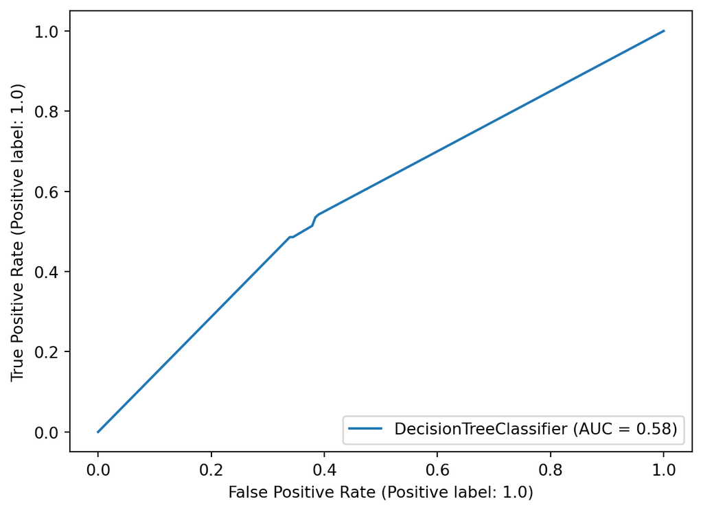

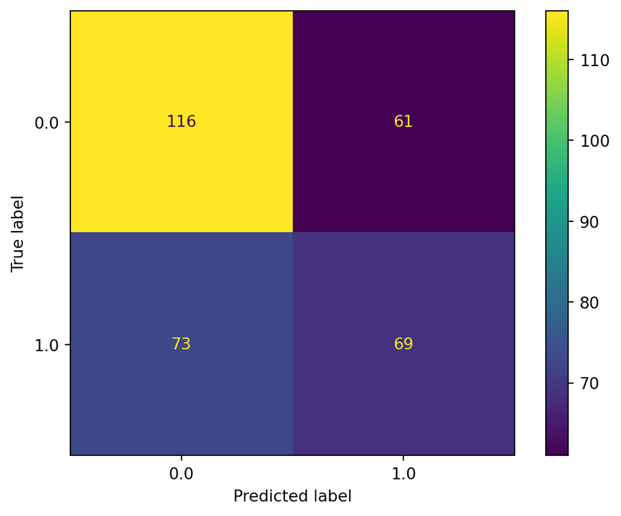

```python
# Include and execute your code here

values_replace1 = {
    '$0 - $24,999': 0,
    '$25,000 - $49,999': 0,
    '$50,000 - $99,999': 1,
    '$100,000 - $149,999': 1,
    '$150,000+': 1}

#%%
war_filtered = war_filtered.replace(values_replace1)

# %%
dummies = pd.get_dummies(war_filtered.filter(['seen_any', 'star_wars_fans', 'view__han_solo',
                                              'view__luke_skywalker', 'view__princess_leia_organa',
                                              'view__anakin_skywalker', 'view__obi_wan_kenobi',
                                              'view__emperor_palpatine', 'view__darth_vader',
                                              'view__lando_calrissian', 'view__boba_fett', 'view__c-3p0',
                                              'view__r2_d2', 'view__jar_jar_binks', 'view__padme_amidala',
                                              'view__yoda', 'shot_first', 'know_expanded', 'expanded_fan',
                                              'star_trek_fan', 'gender', 'age', 'education',
                                              'location_(census_region)']), drop_first=True)

pd.get_dummies(war_filtered['location_(census_region)'])

war_filtered = war_filtered[['household_income']]
war_filtered = war_filtered.fillna(0)

result = pd.concat([war_filtered, dummies], axis=1)

X_pred = result.drop(columns = ['household_income'])
y_pred = result.filter(['household_income'])
X_train, X_test, y_train, y_test = train_test_split(
    X_pred,
    y_pred,
    test_size=.34,
    random_state=76
)

kahoy = tree.DecisionTreeClassifier()
kawayan = kahoy.fit(X_train, y_train)

predictions = kahoy.predict(X_test)

score = kahoy.score(X_test, y_test)
print(score)

metrics.recall_score(y_test, predictions)

metrics.precision_score(y_test, predictions)

metrics.plot_roc_curve(kahoy, X_test, y_test)

metrics.plot_confusion_matrix(kahoy, X_test, y_test)
```

## APPENDIX A (Additional Python Code)

```python
# %%
import pandas as pd
import altair as alt
import numpy as np
import dataclasses as dat
from sklearn.model_selection import train_test_split
from sklearn import tree
from sklearn.naive_bayes import GaussianNB
from sklearn.ensemble import GradientBoostingClassifier
from sklearn import metrics

# Path data
path = 'https://github.com/fivethirtyeight/data/raw/master/star-wars-survey/StarWars.csv'

# Loading in data
war = (pd.read_csv(path, encoding="latin1", nrows=1).melt())
war2 = pd.read_csv(path, encoding="latin1", skiprows=2, header=None)

####################
# GRAND QUESTION 1 #
####################

war = (war
       .replace('Unnamed: \d{1,2}', np.nan, regex=True)
       .replace('Response', "")
       .assign(
               clean_variable=lambda x: x.variable.str.strip()
               .replace('Which of the following Star Wars films have you seen? Please select all that apply.', 'seen'),
           clean_data=lambda x: x.value.str.strip()
           )
           .fillna(method='ffill')
           .assign(
               column_df=lambda x: x.clean_variable.str.cat(
                   x.clean_data, sep="__")
           )
)
war
war.column_df

# we want to use this with the .replace() command that accepts a dictionary.
replace_map = {'Which of the following Star Wars films have you seen\\? Please select all that apply\\.': 'seen',
                     'Please rank the Star Wars films in order of preference with 1 being your favorite film in the franchise and 6 being your least favorite film.': 'rank',
                     'Please state whether you view the following characters favorably unfavorably, or are unfamiliar with him/her.':'view',
                     'Do you consider yourself to be a fan of the Star Trek franchise\\?': 'star_trek_fan',
                     'Do you consider yourself to be a fan of the Expanded Universe\\?\x8cæ': 'expanded_fan',
                     'Are you familiar with the Expanded Universe\\?': 'know_expanded',
                     'Have you seen any of the 6 films in the Star Wars franchise\\?': 'seen_any',
                     'Do you consider yourself to be a fan of the Star Wars film franchise\\?': 'star_wars_fans',
                     'Which character shot first\\?': 'shot_first',
                     'Unnamed: \d{1,2}': np.nan,
                     ' ': '_',
                     }
replace_map

replace_data = {
    'Response': '',
    'Star Wars: Episode ': '',
    ' ': '_'
}

war_use = (war
                .assign(
                    replace_dat=lambda x: x.value.str.strip().replace(replace_data, regex=True),
                    variable_replace=lambda x: x.variable.str.strip().replace(
                        replace_map, regex=True)
                )
                .fillna(method='ffill')
                .fillna(value = "")
           .assign(column_names=lambda x: x.variable_replace.str.cat(x.replace_dat, sep="__").str.strip('__').str.lower())
)

war_use
war2.columns = war_use.column_names.to_list()

####################
# GRAND QUESTION 2 #
####################

# Filter the dataset to respondents that have seen at least one film.

war_filtered = war2.query('seen_any == "Yes"')
Q1 = pd.get_dummies(war_filtered)

# Create a new column that converts the age ranges to a single number.
# Drop the age range categorical column.

age = (war2.age
       .str.split('-', expand=True)
       .rename(columns={0: "min_age", 1: "max_age"})
       .min_age
       .str.replace("> ", "")
       .astype('float'))
age

# Create a new column that converts the education groupings to a single number.
# Drop the school categorical column

education = (war2.education
             .str.split('-', expand=True)
             .rename(columns={0: "min_educ", 1: "max_educ"})
             .min_educ
             .str.replace("> ", ""))
education

# Create a new column that converts the income ranges to a single number.
# Drop the income range categorical column. Create your target
# (also known as “y” or “label”) column based on the new income range column

income = (war2.household_income
                .str.split(' - ', expand=True)
                .rename(columns={0: "min_income", 1: "max_income"})
                .min_income
                .str.replace("\$|,|\+", "", regex=True)
                .astype('float'))
income

war2.assign(min_income=income)

# One-hot encode all remaining categorical columns

init1_dat = pd.get_dummies(war2.filter(
    ['star_trek_fan', 'shot_first']), drop_first=True)

atik_ra = pd.concat([war2, income, init1_dat], axis=1)

####################
# GRAND QUESTION 3 #
####################

war_filtered[['seen__i__the_phantom_menace',
              'seen__ii__attack_of_the_clones',
              'seen__iii__revenge_of_the_sith',
              'seen__iv__a_new_hope',
              'seen__v_the_empire_strikes_back',
              'seen__vi_return_of_the_jedi']] = pd.get_dummies(war_filtered[['seen__i__the_phantom_menace',
                             'seen__ii__attack_of_the_clones',
                             'seen__iii__revenge_of_the_sith',
                             'seen__iv__a_new_hope',
                             'seen__v_the_empire_strikes_back',
                             'seen__vi_return_of_the_jedi']])

g1 = Q1.filter(Q1.columns[10:16])
seen_movie = round(((g1).sum() / len(g1.index) * 100), 2)
G1 = {'title': ["The Phantom Menace",
                "Attack of the Clone",
                "Revenge of the Sith",
                "A New Hope",
                "The Empire Strikes Back",
                "Return of the Jedi"],
      'percent': [71.9, 61, 58.76, 64.85, 80.98, 78.85]}
war_f = pd.DataFrame(data=G1)
war_f

chart1 = (alt.Chart(war_f).mark_bar(color="orange").encode(
    x='percent',
    y=alt.Y('title', sort=['The Phantom Menace',
                           'Attack of the Clone',
                           'Revenge of the Sith',
                           'A New Hope',
                           'The Empire Strikes Back',
                           'Return of the Jedi'],
            axis=alt.Axis(title=''))
).properties(title="Which 'Star Wars' Movies Have You Seen?"))
chart1

war_dont = war_filtered.query(
    'shot_first == "I don\'t understand this question"')
war_han = war_filtered.query('shot_first == "Han"')
war_greed = war_filtered.query('shot_first == "Greedo"')

G2 = {'person':["Han",
                "Greedo",
                "I don't understand this question"],
      'percent': [34.72, 21.04, 32.69,]}

df1 = pd.DataFrame(data=G2)

chart2 = (alt.Chart(df1).mark_bar(color="blue").encode(
    x='percent',
    y=alt.Y('person', sort=['Han',
                            'Greedo',
                            'I don\'t understand this question'],
            axis=alt.Axis(title=''))).properties(title="Who Shot First?"))
chart2

####################
# GRAND QUESTION 4 #
####################

values_replace1 = {
    '$0 - $24,999': 0,
    '$25,000 - $49,999': 0,
    '$50,000 - $99,999': 1,
    '$100,000 - $149,999': 1,
    '$150,000+': 1}

#%%
war_filtered = war_filtered.replace(values_replace1)

# %%
dummies = pd.get_dummies(war_filtered.filter(['seen_any', 'star_wars_fans', 'view__han_solo',
                                              'view__luke_skywalker', 'view__princess_leia_organa',
                                              'view__anakin_skywalker', 'view__obi_wan_kenobi',
                                              'view__emperor_palpatine', 'view__darth_vader',
                                              'view__lando_calrissian', 'view__boba_fett', 'view__c-3p0',
                                              'view__r2_d2', 'view__jar_jar_binks', 'view__padme_amidala',
                                              'view__yoda', 'shot_first', 'know_expanded', 'expanded_fan',
                                              'star_trek_fan', 'gender', 'age', 'education',
                                              'location_(census_region)']), drop_first=True)

pd.get_dummies(war_filtered['location_(census_region)'])

war_filtered = war_filtered[['household_income']]
war_filtered = war_filtered.fillna(0)

result = pd.concat([war_filtered, dummies], axis=1)

X_pred = result.drop(columns = ['household_income'])
y_pred = result.filter(['household_income'])
X_train, X_test, y_train, y_test = train_test_split(
    X_pred,
    y_pred,
    test_size=.34,
    random_state=76
)

# Decision tree
kahoy = tree.DecisionTreeClassifier()
kawayan = kahoy.fit(X_train, y_train)

# Predisions X_test
predictions = kahoy.predict(X_test)

# Score x_test and y_test
score = kahoy.score(X_test, y_test)
print(score)

# Predictions y_test
metrics.recall_score(y_test, predictions)

# Score y_test
metrics.precision_score(y_test, predictions)

# Plot_roc_curve x_test, y_test
metrics.plot_roc_curve(kahoy, X_test, y_test)

# Plot_confusion_matrix x_test, y_test
metrics.plot_confusion_matrix(kahoy, X_test, y_test)
```